# Exploratory Data Visualization of Blight and Demolitions in Detroit, Michigan

Lauren Li

## Introduction

Like many other metropolitan cities, Detroit suffers from derelict properties decaying from years of abandonment and disuse. Abandoned buildings often lower the values of surrounding properties and are linked to increased rates of crime. The city of Detroit has several methods of combatting blight and vacant buildings: monetary violations, demolitions, and sales of publically-owned land.

```r
#color scheme
#gray, light purple, darker purple, dark purple
#light orange, light blue, light green
primary <- c('#D3D3D3', '#8C82FA', '#6408A1','#31044F')
secondary <- c('#ED9007','#14E5D0', '#B0EE31')

#theme
my_theme <- theme(text = element_text(family="Helvetica", color = 'black'),
                  plot.title = element_text(size = 14, face = 'bold'),
                  plot.subtitle = element_text(size = 12),
                  plot.caption = element_text(size = 8),
                  panel.background = element_rect(fill = "white"),
                  plot.background = element_rect(fill = "white"),
                  axis.line = element_line(colour = "black"),
                  axis.title.y = element_text(size = 10, angle = 90),
                  axis.title.x = element_text(size = 10),
                  panel.grid.major = element_blank(),
                  panel.grid.minor = element_blank(),
                  axis.ticks.length = unit(.15, "cm"),
                  legend.box.margin = margin(6, 6, 6, 6),
                  legend.text = element_text(size = 10, colour = "black"))

map_theme <- my_theme + theme(panel.grid.major = element_line(color = "white"), panel.grid.minor = element_blank(), axis.line = element_blank(), axis.ticks = element_blank(), axis.text = element_blank(), axis.title = element_text(color='white'))
```

## Blight Violations

Blight tickets are fines issued to property owners for infractions regarding the maintenance of their property’s exterior. The city of Detroit issues thousands of blight violations every month, with spikes in the summer and fall months. Blight violations peaked around the recession and started to decrease into 2012 and 2013. Since then, however, the number of violations has trended upward and is starting to reach recession-level highs again.

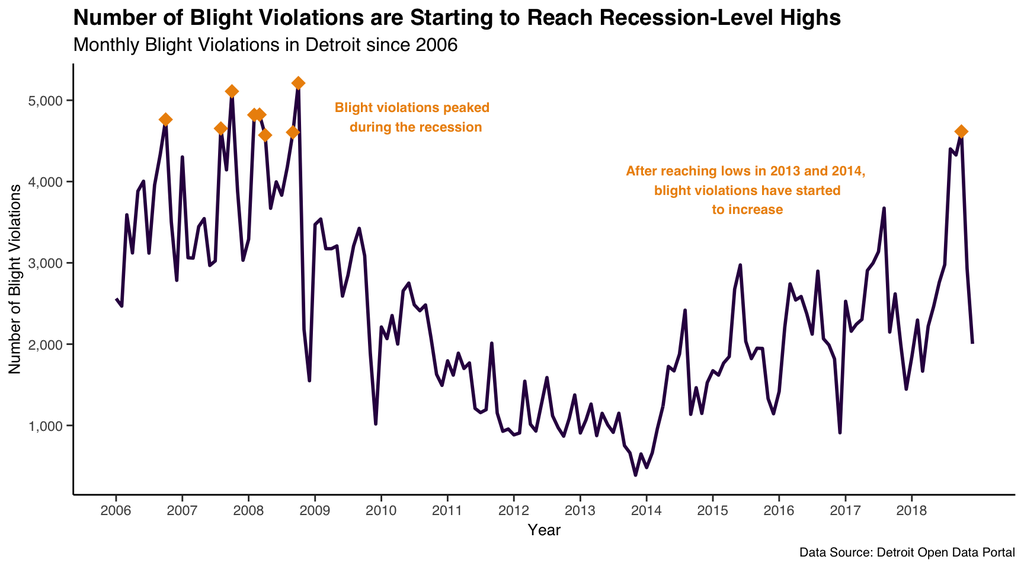

```r
blight_tix %<>% mutate(`Violation Date` = as.Date(`Violation Date`,format = "%m/%d/%Y")) %>%
  mutate(year = as.numeric(strftime(`Violation Date`, '%Y'))) %>%
  mutate(month = as.numeric(strftime(`Violation Date`, '%m'))) %>%
  mutate(month_year = `Violation Date`) %>%
  mutate(month_year = as.Date(paste(strftime(month_year, '%Y-%m-'),'15',sep='')))



#Number of blight violations reaching recession-levels (could become radial?)
all_counts <- blight_tix %>%
  filter(year > 2005) %>%
  filter(year < 2019) %>%
  group_by(month_year, year) %>%
  summarize(count = n(),amount=sum(`Judgment Amount (Total Due)`), pertick = amount/count)

counts_over_4500 <- all_counts %>%
  filter(count > 4500)

counts_under_1000 <- all_counts %>%
  filter(count < 1000)

all_counts %>%
  ggplot(aes(x=month_year, y=count)) +
  my_theme +
  geom_line(size=1, color = '#31044F') +
  geom_point(data = counts_over_4500, aes(x=month_year, y=count), color = '#ED9007', size =4, shape='diamond') +
  annotate('text', x=as.Date('2010-07-15'), y=4800, label = 'Blight violations peaked \n during the recession', fontface='bold', size=3, family = my_theme$text[['family']], color = '#ED9007') +
  annotate('text', x=as.Date('2015-07-15'), y=3900, label = 'After reaching lows in 2013 and 2014,\n blight violations have started\n to increase', fontface='bold', size=3, family = my_theme$text[['family']], color = '#ED9007') +
  scale_x_date(breaks = seq(as.Date("2006-01-15"), as.Date("2018-12-15"), by="12 months"), date_labels = "%Y") +
  scale_y_continuous(labels=comma) +
  labs(title = 'Number of Blight Violations are Starting to Reach Recession-Level Highs', subtitle = 'Monthly Blight Violations in Detroit since 2006', x = 'Year', y='Number of Blight Violations', caption = 'Data Source: Detroit Open Data Portal')
```

## Blight Violation Noncompliance

Detroit is struggling to enforce the maintenance of property standards on privately-owned land. Despite many ticket issuances, noncompliance with blight violations is very high. Since 2006, only about a quarter of tickets are paid in full each year.

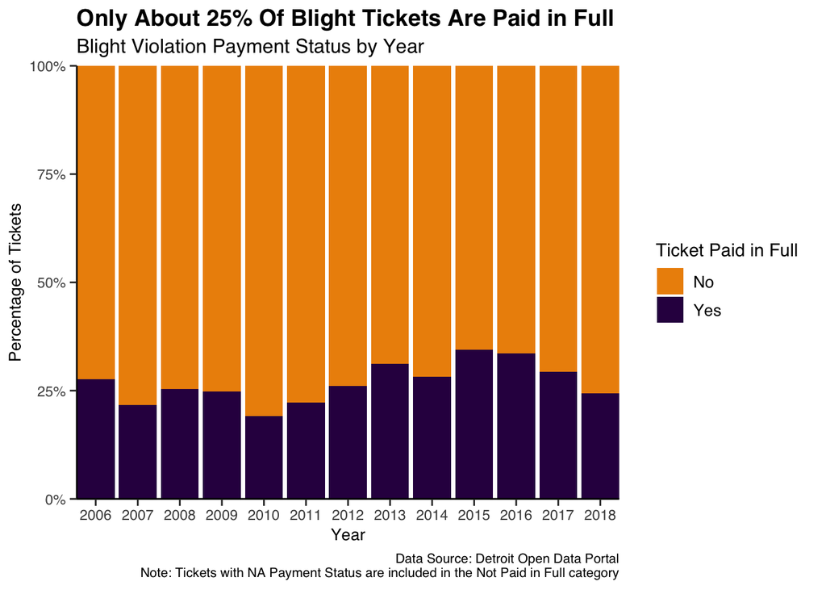

```r
#violations with an amount due and balance due > 0 but NA payment status -> bar chart
blight_tix %>%
  filter(`Judgment Amount (Total Due)` > 0) %>%
  filter(`Balance Due` >= 0) %>%
  filter(year > 2005) %>%
  filter(year < 2019) %>%
  mutate(paid = ifelse(`Payment Status` == 'PAID IN FULL', 'Yes', 'No')) %>%
  mutate(paid = replace_na(paid, 'No')) %>%
  mutate(paid = factor(paid, levels = c('No','Yes'))) %>%
  group_by(year, paid) %>%
  summarize(count=n()) %>%
  ggplot(aes(x=year, y=count, fill=paid)) +
  geom_bar(stat='identity', position='fill') +
  my_theme +
  scale_fill_manual(values = c('#ED9007', '#31044F')) +
  scale_x_continuous('Year', expand = c(0,0), breaks =seq(2006,2018,1), labels = c('2006','2007','2008','2009','2010','2011','2012','2013','2014','2015','2016','2017','2018')) +
  scale_y_continuous('Percentage of Tickets', expand = c(0,0), breaks =seq(0,1,0.25), labels = c('0%','25%','50%','75%','100%')) +
  labs(title='Only About 25% Of Blight Tickets Are Paid in Full', subtitle = 'Blight Violation Payment Status by Year', caption = 'Data Source: Detroit Open Data Portal\nNote: Tickets with NA Payment Status are included in the Not Paid in Full category', y = 'Number of Blight Tickets', fill = 'Ticket Paid in Full')
```

## Relationship Between Blight Violations and the Demolitions Program

While blight plagues the entire city, it is more concentrated in some areas than others. The southern tip of District 7 (West Detroit) and the eastern part of District 4 (East Detroit) had a highly concentrated number of blight tickets issued in 2018.

To maintain publically-owned blighted and abandoned land, Detroit has one of the largest demolitions programs in the country. The city spends tens of millions of dollars each year to demolish thousands of buildings. Notably, the city’s demolition efforts and blight violations are concentrated in the same areas (Districts 4 and 7).

You can compare the concentration of blight and demolitions in 2018 in the two visualizations below.

*If you are interested in why the map of Detroit has a large gap in the middle of the city, check out this [article provided by the WDET](https://wdet.org/posts/2014/09/19/80119-why-do-hamtramck-and-highland-park-exist-inside-the-city-of-detroit/)!

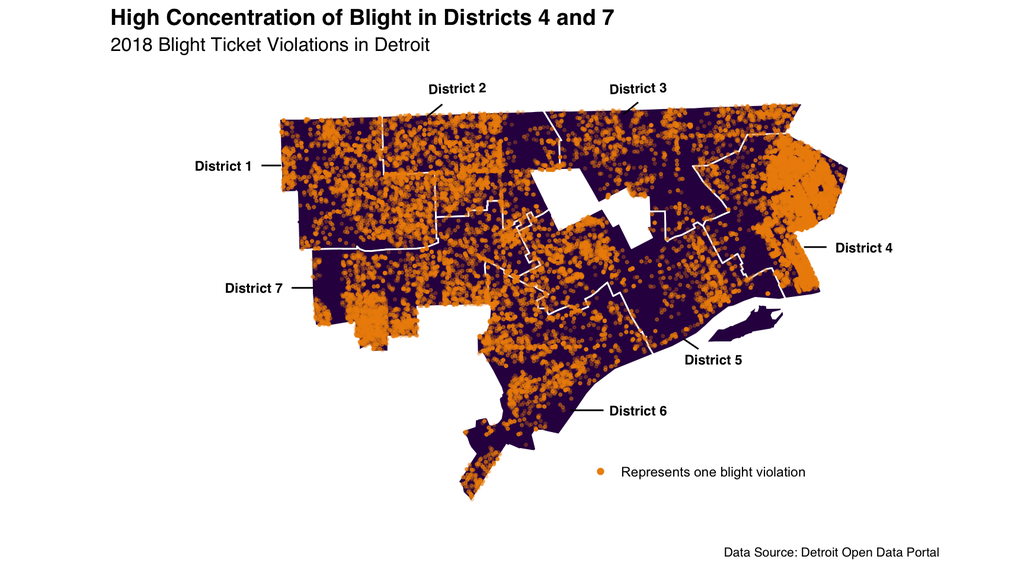

```r
#Blight Violations by District

f <- 'geo_export_c0cba125-2fb0-432f-9a11-e6bb3c7dd89e.shp'

districts_shp <- st_read(here('detroit_data','City Council Districts',f))

max_long <- range(st_coordinates(districts_shp))[1]
max_lat <- range(st_coordinates(districts_shp))[2]

blight_2018 <- blight_tix %>%
  mutate(year = as.Date(`Violation Date`,format = "%m/%d/%Y")) %>%
  mutate(year = as.numeric(strftime(year, '%Y'))) %>%
  filter(year==2018) %>%
  filter(`Violation Latitude` < max_lat) %>%
  filter(`Violation Longitude` > max_long)

blight_points <- data.frame('Long' = blight_2018$`Violation Longitude`, 'Lat' = blight_2018$`Violation Latitude`)
tmp <- st_as_sf(blight_points, coords = c('Long','Lat'), crs=st_crs(districts_shp)[[1]])
tmp <- st_transform(tmp, crs = st_crs(districts_shp)[[2]])
tmp <- st_intersection(districts_shp, tmp)
dots <- data.frame(st_coordinates(tmp))

blight_map <- ggplot() +
  geom_sf(data = districts_shp, fill = '#31044F', color = 'white') +
  geom_point(data = dots, aes(x=X, y=Y), size = 0.6, color = '#ED9007', fill = "#ED9007", alpha=0.25) +
  annotate('text', x = -83.325, y = 42.42, label = 'District 1', color = 'black', size =3, family = my_theme$text[['family']], fontface='bold') +
  annotate("segment", x = -83.3, xend = -83.287, y = 42.42, yend = 42.42, color = 'black') +
  annotate('text', x = -83.17, y = 42.458, label = 'District 2', color = 'black', angle = 2, size = 3, family = my_theme$text[['family']], fontface='bold') +
  annotate("segment", x = -83.18, xend = -83.19, y = 42.45, yend = 42.444, color = 'black') +
  annotate('text', x = -83.05, y = 42.458, label = 'District 3', color = 'black', angle = 2, size = 3, family = my_theme$text[['family']], fontface='bold') +
  annotate("segment", x = -83.05, xend = -83.06, y = 42.451, yend = 42.445, color = 'black') +
  annotate('text', x = -83.305, y = 42.36, label = 'District 7', color = 'black', size = 3, family = my_theme$text[['family']], fontface='bold') +
  annotate("segment", x = -83.28, xend = -83.265, y = 42.36, yend = 42.36, color = 'black') +
  annotate('text', x = -83.05, y = 42.3, label = 'District 6', color = 'black', size = 3, family = my_theme$text[['family']], fontface='bold') +
  annotate("segment", x = -83.095, xend = -83.073, y = 42.3, yend = 42.3, color = 'black') +
  annotate('text', x = -83, y = 42.325, label = 'District 5', color = 'black', size = 3, family = my_theme$text[['family']], fontface='bold') +
  annotate("segment", x = -83.02, xend = -83.01, y = 42.335, yend = 42.33, color = 'black') +
  annotate('text', x = -82.9, y = 42.38, label = 'District 4', color = 'black', size = 3, family = my_theme$text[['family']], fontface='bold') +
  annotate("segment", x = -82.94, xend = -82.925, y = 42.38, yend = 42.38, color = 'black') +
  coord_sf(xlim = c(-83.4, -82.85), ylim = c(42.25, 42.47), expand = FALSE) +
  map_theme +
  labs(title = 'High Concentration of Blight in Districts 4 and 7', subtitle = '2018 Blight Ticket Violations in Detroit', caption = 'Data Source: Detroit Open Data Portal') +
  annotate('point', x = -83.075, y = 42.27, color = '#ED9007', fill = "#ED9007") +
  annotate('text', x = -83, y = 42.27, label = 'Represents one blight violation', size=3)

blight_map
```

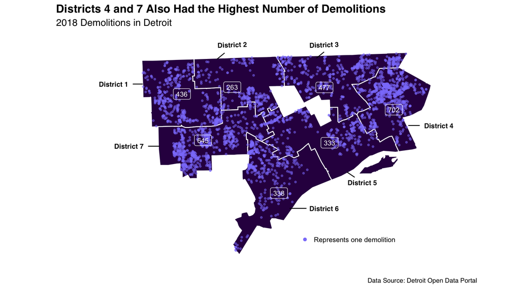

```r
past_demolitions %<>%
  mutate(`Demolition Date` = as.Date(`Demolition Date`,format = "%m/%d/%Y")) %>%
  mutate(month_year = `Demolition Date`) %>%
  mutate(year = as.numeric(strftime(`Demolition Date`, '%Y'))) %>%
  mutate(month = as.numeric(strftime(`Demolition Date`, '%m'))) %>%
  mutate(month_year = as.Date(paste(strftime(month_year, '%Y-%m-'),'15',sep='')))

sym <- past_demolitions %>%
  filter(year==2018)

ct <- sym %>%
  mutate(districts = as.factor(Council_District)) %>%
  group_by(districts) %>%
  summarize(count=n())

all <- left_join(districts_shp, ct, by = 'districts')

dem_map <- ggplot() +
  geom_sf(data = all, fill = '#31044F', color = 'white') +
  geom_point(data = sym, aes(x=Longitude, y=Latitude), size = 0.85, color = '#8C82FA', alpha=0.5) +
  geom_sf_label(data = all, aes(label = count), color = 'white', size = 3, fill = NA) +
  scale_size(range = c(4, 12)) +
  annotate('text', x = -83.325, y = 42.42, label = 'District 1', color = 'black', size =3, family = my_theme$text[['family']], fontface='bold') +
    annotate("segment", x = -83.3, xend = -83.287, y = 42.42, yend = 42.42, color = 'black') +
    annotate('text', x = -83.17, y = 42.458, label = 'District 2', color = 'black', angle = 2, size = 3, family = my_theme$text[['family']], fontface='bold') +
    annotate("segment", x = -83.18, xend = -83.19, y = 42.45, yend = 42.444, color = 'black') +
    annotate('text', x = -83.05, y = 42.458, label = 'District 3', color = 'black', angle = 2, size = 3, family = my_theme$text[['family']], fontface='bold') +
    annotate("segment", x = -83.05, xend = -83.06, y = 42.451, yend = 42.445, color = 'black') +
    annotate('text', x = -83.305, y = 42.36, label = 'District 7', color = 'black', size = 3, family = my_theme$text[['family']], fontface='bold') +
    annotate("segment", x = -83.28, xend = -83.265, y = 42.36, yend = 42.36, color = 'black') +
    annotate('text', x = -83.05, y = 42.3, label = 'District 6', color = 'black', size = 3, family = my_theme$text[['family']], fontface='bold') +
    annotate("segment", x = -83.095, xend = -83.073, y = 42.3, yend = 42.3, color = 'black') +
    annotate('text', x = -83, y = 42.325, label = 'District 5', color = 'black', size = 3, family = my_theme$text[['family']], fontface='bold') +
    annotate("segment", x = -83.02, xend = -83.01, y = 42.335, yend = 42.33, color = 'black') +
    annotate('text', x = -82.9, y = 42.38, label = 'District 4', color = 'black', size = 3, family = my_theme$text[['family']], fontface='bold') +
    annotate("segment", x = -82.94, xend = -82.925, y = 42.38, yend = 42.38, color = 'black') +
    coord_sf(xlim = c(-83.4, -82.85), ylim = c(42.25, 42.47), expand = FALSE) +
    map_theme +
    labs(title = 'Districts 4 and 7 Also Had the Highest Number of Demolitions', subtitle = '2018 Demolitions in Detroit', caption = 'Data Source: Detroit Open Data Portal') +
    annotate('point', x = -83.075, y = 42.27, color = '#8C82FA', fill = "#8C82FA") +
    annotate('text', x = -83.01, y = 42.27, label = 'Represents one demolition', size=3)

dem_map
```

## Cost of Demolition

The Hardest Hit Funding program is the largest of the city’s funding sources for its demolition program, which, by law, can be spent only in federally-designated areas of the city. The funds are split across the city to carry out demolitions. The program has a limit of $25,000 per building so there are cases in which a house switches to non-HHF or uses city funds to cover additional costs exceeding the program limit.

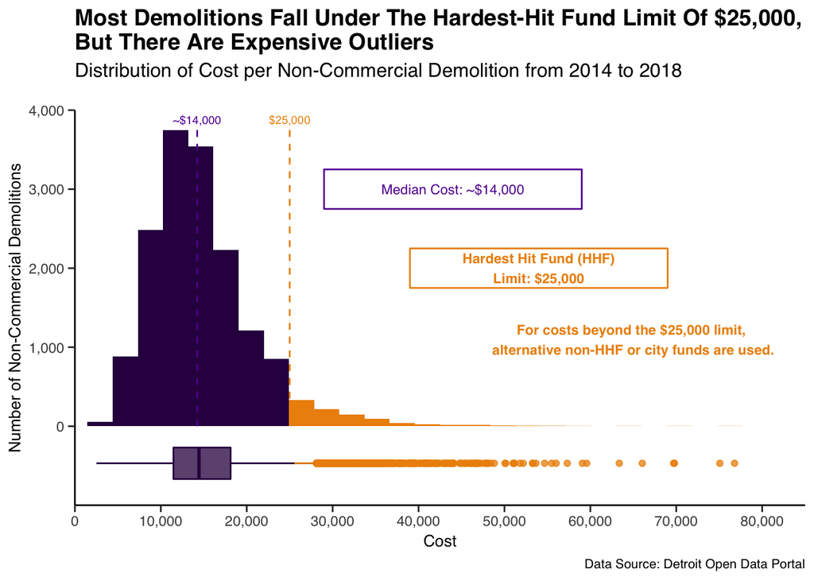

```r
non_com <- past_demolitions %>%
  filter(`Commercial Building` == 'No') %>%
  mutate(demolitions=factor('Name')) %>%
  filter(!is.na(Price)) %>%
  filter(Price > 500) %>%
  filter(year < 2019)

box <- ggplot() +
  geom_boxplot(data = non_com, aes(y=Price), color = "#31044F", fill = "#31044F", alpha=0.75,
               outlier.colour = '#ED9007') +
  annotate('segment', x=0, xend=0, y=25000, yend=28000, color = '#ED9007') +
  coord_flip() +
  scale_y_continuous(expand=c(0,0), limits = c(0,80000)) +
  my_theme +
  theme(axis.text.y = element_blank(),
        axis.ticks.y = element_blank(),
        axis.title.y = element_blank(),
        axis.line.y = element_blank(),
        axis.title.x = element_blank(),
        axis.ticks.x = element_blank(),
        axis.text.x = element_text(color='white'),
        axis.line.x = element_blank(),
        plot.margin=unit(c(0,0,0,0),"cm"))

p2 <- as.grob(box)

colors <- c(rep('#31044F', 9), rep('#ED9007',21))

hist2 <- ggplot(data=non_com) +
  geom_histogram(aes(x=Price), fill = colors) +
  my_theme +
  scale_y_continuous(expand=c(0,0), limits= c(-1000,4000), breaks=seq(0,4000,1000), labels=comma) +
  scale_x_continuous(expand=c(0,0), labels=comma, limits = c(0,85000), breaks=seq(0,85000,10000)) +
  labs(title = 'Most Demolitions Fall Under The Hardest-Hit Fund Limit Of $25,000,\nBut There Are Expensive Outliers', subtitle='Distribution of Cost per Non-Commercial Demolition from 2014 to 2018\n', caption = 'Data Source: Detroit Open Data Portal', y = 'Number of Non-Commercial Demolitions', x = 'Cost') +
  annotate('segment', x =14235, xend = 14235, y =0, yend = 3750, color = '#6408A1', linetype='dashed') +
  annotate('segment', x =25000, xend = 25000, y =0, yend = 3750, color = "#ED9007", linetype= 'dashed') +
  annotate('rect', xmin=29000, xmax=59000, ymin= 2750, ymax=3250, color = '#6408A1', fill = NA) +
  annotate('rect', xmin=39000, xmax=69000, ymin= 1750, ymax=2250, color = "#ED9007", fill = NA) +
  annotate('text', x = 44000, y =3000, color = '#6408A1', label = 'Median Cost: ~$14,000', size=3,
           family = my_theme$text[['family']]) +
  annotate('text', x = 54000, y =2000, color = "#ED9007", label = 'Hardest Hit Fund (HHF)\nLimit: $25,000',
           fontface='bold', size=3, family = my_theme$text[['family']]) +
  annotate('text', x=14235, y = 3880, label = '~$14,000', color = '#6408A1', size=2.5,
           family = my_theme$text[['family']]) +
  annotate('text', x=25000, y = 3880, label = '$25,000', color = "#ED9007", size=2.5) +
  annotate('text', x = 65000, y =1100, color = "#ED9007",
           label = 'For costs beyond the $25,000 limit, \nalternative non-HHF or city funds are used.',
           fontface='bold', family = my_theme$text[['family']],size=3)

hist2 +
  annotation_custom(
    grob = p2,
    xmin = 0,
    xmax = 80000,
    ymin = -1000,
    ymax = -250
  )
```

## Side Lot Sales

After demolition, a number of lots are sold through a program that sells side lots in the Detroit Land Bank Authority’s inventory for $100. The program is meant to encourage private and community investment in neighborhoods and reduce the number of properties in public ownership. Taking a look at side lot sales in each neighborhood since 2015, Claytown stands out with over a hundred lots sold each year. Airport Sub, Chadsey Condon, and Brightmoor also had a sizeable number of side lot sales compared to the rest of the neighborhoods.

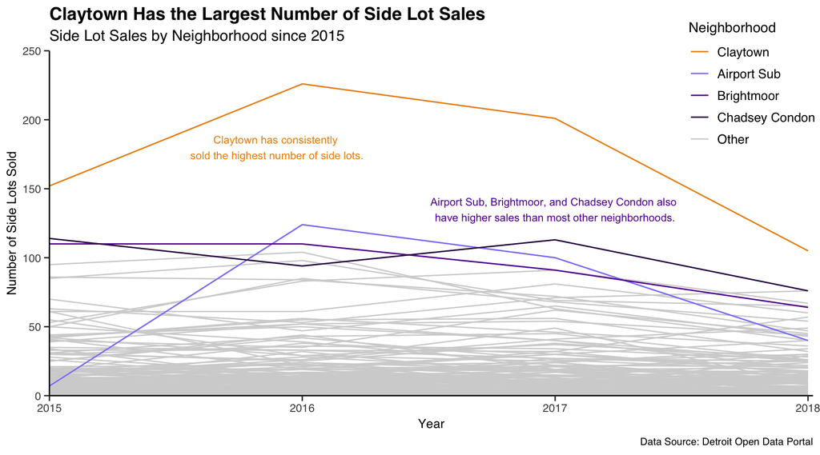

```r
side_lot_sales %<>%
  mutate(`Closing Date` = as.Date(`Closing Date`,format = "%m/%d/%Y")) %>%
  mutate(year = `Closing Date`) %>%
  mutate(year = as.numeric(strftime(year, '%Y'))) %>%
  mutate(month= `Closing Date`) %>%
  mutate(month = as.numeric(strftime(month, '%m'))) %>%
  mutate(category = 'Side Lot Sale')

neighborhoods <- c('Brightmoor','Claytown','Airport Sub','Chadsey Condon','Penrose')


top_5 <- side_lot_sales %>%
  filter(`Neighborhood` %in% neighborhoods) %>%
  mutate(`Neighborhood` = ifelse(`Neighborhood` == 'Penrose', 'Other', `Neighborhood`)) %>%
  group_by(`Neighborhood`, year) %>%
  filter(year >= 2015) %>%
  filter(year != 2019) %>%
  summarize(count=n())

num <- length(unique(side_lot_sales$Neighborhood))

avg <- side_lot_sales %>%
  filter(year >= 2015) %>%
  filter(year != 2019) %>%
  group_by(year) %>%
  summarize(count = n(), a = count/num)


#line graph: Side lot sales by (select) neighborhood and year
side_lot_sales %>%
  group_by(`Neighborhood`, year) %>%
  filter(year >= 2015) %>%
  filter(year != 2019) %>%
  summarize(count=n()) %>%
  ggplot(aes(x=year, y=count, group=`Neighborhood`)) +
  geom_line(color='#D3D3D3') +
  geom_line(data=top_5, aes(x=year, y=count, color=`Neighborhood`)) +
  scale_colour_manual(values=c('Claytown' = '#ED9007', 'Airport Sub' = '#8C82FA', 'Brightmoor' = '#6408A1', 'Chadsey Condon' = '#31044F', 'Other' = '#D3D3D3'),
                       name="Neighborhood", breaks=c("Claytown", "Airport Sub", "Brightmoor", 'Chadsey Condon', 'Other'),
                       labels=c("Claytown", "Airport Sub", "Brightmoor", 'Chadsey Condon', 'Other')) +
  my_theme +
  theme(legend.position = c(0.92,0.9),legend.key=element_blank()) +
  scale_x_continuous(expand=c(0,0), lim = c(2015,2018.02)) + scale_y_continuous(expand=c(0,0), lim = c(0,250)) +
  labs(title = 'Claytown Has the Largest Number of Side Lot Sales', subtitle ='Side Lot Sales by Neighborhood since 2015', x='Year', y='Number of Side Lots Sold', caption = 'Data Source: Detroit Open Data Portal') +
  annotate('text', x=2015.9, y = 180, label ='Claytown has consistently \nsold the highest number of side lots.', color = '#ED9007', size=3) +
  annotate('text', x=2017, y = 135, label ='Airport Sub, Brightmoor, and Chadsey Condon also \nhave higher sales than most other neighborhoods.', color = '#6408A1', size=3)
```

## Other Programs to Sell City-Owned Land

The side lot sales program is just one component of the Detroit Land Bank Authority. DLBA is a public agency and the city’s largest landowner with a number of vacant lots and abandoned houses. The side lot sales program is by far the most active by number of properties sold; however, the DLBA has increased its efforts to sell structures through Auctions and its “Own It Now” Program over the past couple of years.

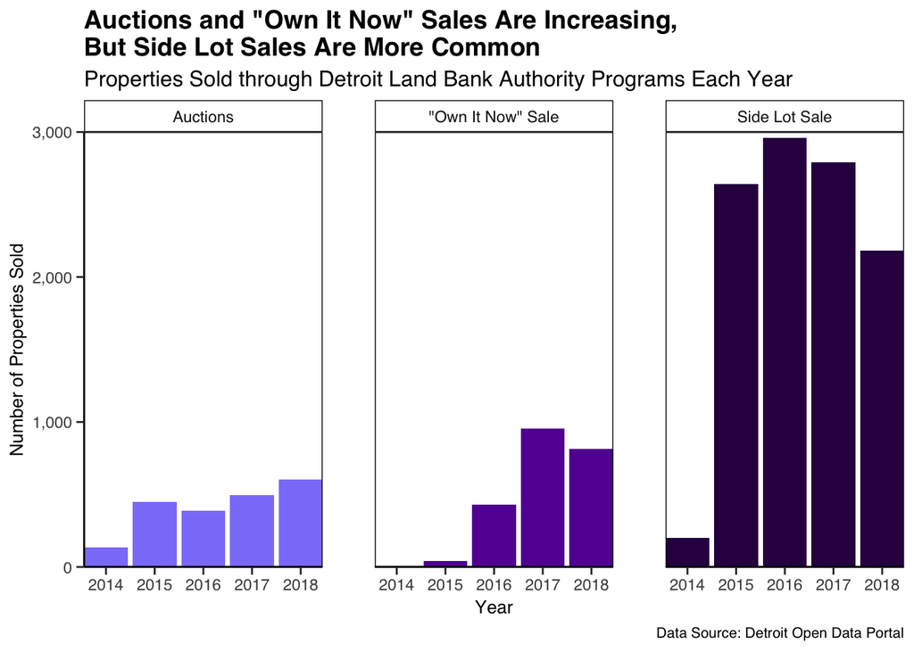

```r
auctions %<>%
  mutate(`Closing Date` = as.Date(`Closing Date`,format = "%m/%d/%Y")) %>%
  mutate(year = `Closing Date`) %>%
  mutate(year = as.numeric(strftime(year, '%Y'))) %>%
  mutate(month= `Closing Date`) %>%
  mutate(month = as.numeric(strftime(month, '%m'))) %>%
  mutate(category = 'Auctions')

own_it_now %<>%
  mutate(`Closing Date` = as.Date(`Closing Date`,format = "%m/%d/%Y")) %>%
  mutate(year = `Closing Date`) %>%
  mutate(year = as.numeric(strftime(year, '%Y'))) %>%
  mutate(month= `Closing Date`) %>%
  mutate(month = as.numeric(strftime(month, '%m'))) %>%
  mutate(category = '"Own It Now" Sale')

a <- auctions %>%
  filter(year > 2013 & year < 2019) %>%
  group_by(category, year) %>%
  summarize(count = n())

b <- own_it_now %>%
  filter(year > 2013 & year < 2019) %>%
  group_by(category, year) %>%
  summarize(count = n())

c <- side_lot_sales %>%
  filter(year > 2013 & year < 2019) %>%
  group_by(category,year) %>%
  summarize(count = n())

all_three <- rbind(a,b)
all_three <- rbind(all_three,c)


ggplot(all_three, aes(x=year, y=count)) +
  geom_bar(stat='identity') +
  facet_grid(cols = vars(factor(category, levels = c('Auctions', '"Own It Now" Sale', 'Side Lot Sale')))) +
  aes(fill = as.factor(category)) +
  scale_fill_manual(values=c('#6408A1','#8C82FA', '#31044F')) +
  my_theme +
  theme(strip.background = element_rect(fill='white',color='black'),
        panel.border = element_rect(colour = "black", fill = NA),
        legend.position = 'none',
        panel.spacing = unit(2, 'lines')) +
  scale_y_continuous(expand=c(0,0), labels=comma, limits = c(0,3000)) + scale_x_continuous(expand=c(0,0)) +
  labs(title = 'Auctions and "Own It Now" Sales Are Increasing,\nBut Side Lot Sales Are More Common', subtitle = 'Properties Sold through Detroit Land Bank Authority Programs Each Year', caption = 'Data Source: Detroit Open Data Portal', x='Year', y='Number of Properties Sold')
```

## Land Sales Across Detroit

While the Detroit Land Bank Authority has increased its land sales over the past couple of years, the sales are not evenly distributed among areas within Detroit. Specifically, a large number of sales occurred in Western and Eastern Detroit but very few in the central and Downtown areas. It is worth noting that Western and Eastern Detroit also had the highest number of blight violations and demolitions in 2018.

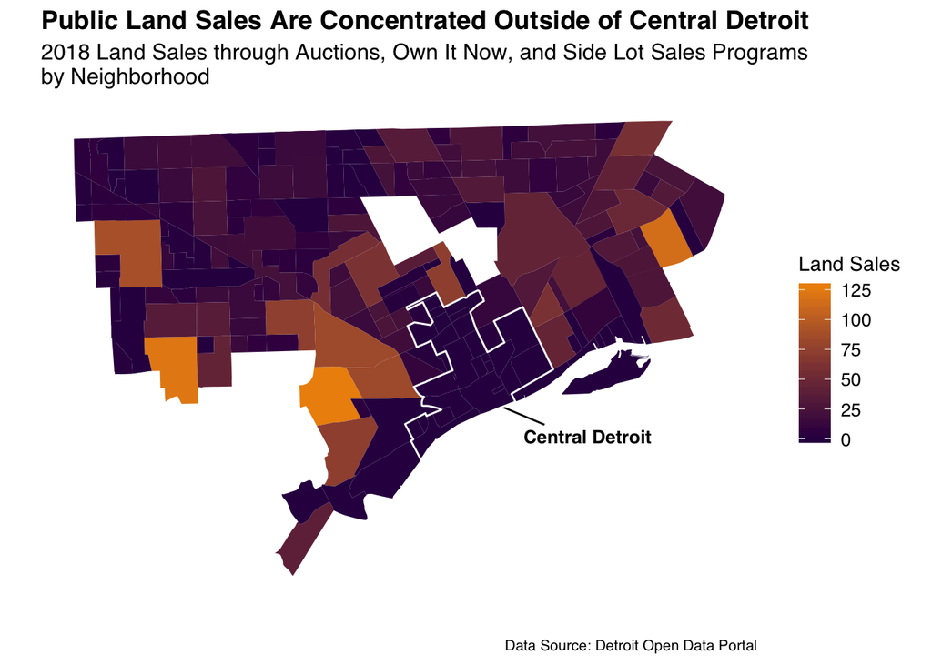

```r
f <- 'geo_export_30086289-81b8-46bd-bbf7-9d8d3ae67dce.shp'

neighbor_shp <- st_read(here('detroit_data','Detroit Neighborhoods',f))

o <- own_it_now %>%
  filter(year==2018) %>%
  group_by(Neighborhood) %>%
  summarize(count=n())

o <- data.frame(o)
colnames(o) <- c('nhood_name', 'own_now')

a <- auctions %>%
  filter(year==2018) %>%
  group_by(Neighborhood) %>%
  summarize(count=n())

a <- data.frame(a)
colnames(a) <- c('nhood_name', 'auctions')

s <- side_lot_sales %>%
  filter(year==2018) %>%
  group_by(Neighborhood) %>%
  summarize(count=n())

s <- data.frame(s)
colnames(s) <- c('nhood_name', 'sidelots')

n <- data.frame('nhood_name' = neighbor_shp$nhood_name)

t <- left_join(n, s, by='nhood_name')
tmp <- left_join(t, a, by='nhood_name')

both <- left_join(tmp, o, by='nhood_name') %>%
  mutate(auctions = replace_na(auctions, 0)) %>%
  mutate(own_now = replace_na(own_now, 0)) %>%
  mutate(sidelots = replace_na(sidelots, 0)) %>%
  mutate(total = auctions + own_now + sidelots)

for_graph <- both %>% select(nhood_name, total)

x <- left_join(neighbor_shp, for_graph, by = 'nhood_name')

low <- x %>% filter(total < 2) %>% filter(district_n == 5 | district_n == 6)

outside <- c('Oakwood Heights', 'Carbon Works', 'Delray', 'Arden Park', 'Belle Isle', 'Gold Coast', 'Indian Village',
             'Rivertown', 'Marina District', 'Waterworks Park', 'Joseph Berry Sub', 'Jeffries', 'Southwest Detroit',
             'Russell Industrial')
low %<>% filter(!nhood_name %in% outside)
border <- st_union(low)

ggplot() +
  annotate("segment", x = -83.047, xend = -83.015, y = 42.33, yend = 42.32, color = 'black') +
  geom_sf(data = x, aes(fill=total), lwd=0) +
  geom_sf(data=border, color = 'white', fill = NA) +
  annotate("segment", x = -83.068, xend = -83.065, y = 42.3424, yend = 42.337, color = '#31044F') +
  scale_fill_gradient(name ='Land Sales', low = '#31044F', high = '#ED9007') +
  map_theme +
  labs(title = 'Public Land Sales Are Concentrated Outside of Central Detroit', subtitle = '2018 Land Sales through Auctions, Own It Now, and Side Lot Sales Programs \nby Neighborhood', caption = 'Data Source: Detroit Open Data Portal') +
  annotate('text', x = -82.99, y = 42.315, label = 'Central Detroit', color = 'black', size = 3.5, family = my_theme$text[['family']], fontface='bold')
```

## Detroit Land Bank Inventory

Lack of public land sales in the Downtown Detroit area is not necessarily due to lack of interest in the central part of the city. In fact, the downtown area has the most city-owned vacant land that is not for sale. The buildup of city-owned land that is not on the market is often a frustrating barrier for those interested in buying property in the city. A large portion of the Detroit Land Bank Authority’s inventory is categorized as Vacant Land as opposed to property that is for sale to private owners. There is a particularly high number of Vacant Land properties compared to other inventory types in District 5, which includes the downtown Detroit area.

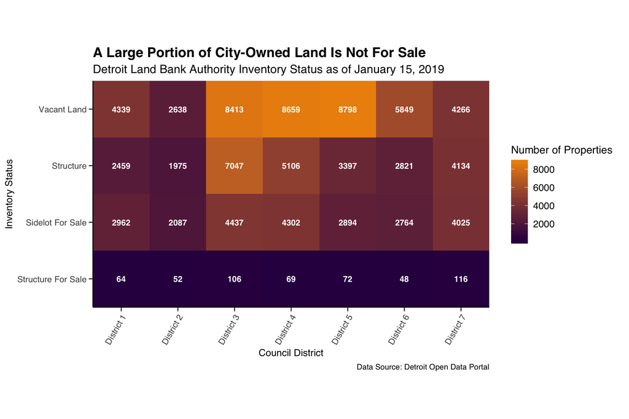

```r
#Heatmap
district_own <- land_inv %>%
  mutate(District = paste('District', `Council District`)) %>%
  mutate(`Inventory Status` = str_remove(`Inventory Status`, 'DLBA Owned ')) %>%
  group_by(District,`Inventory Status`) %>%
  summarize(count=n())

district_own <- data.frame(district_own)

district_own %>%
  ggplot(aes(x=District, y=fct_rev(factor(Inventory.Status, levels = c('Vacant Land', 'Structure','Sidelot For Sale', 'Structure For Sale'))), fill=count)) +
  geom_tile() +
  labs(title = "A Large Portion of City-Owned Land Is Not For Sale", subtitle = 'Detroit Land Bank Authority Inventory Status as of January 15, 2019', y = 'Inventory Status', x='Council District', caption = 'Data Source: Detroit Open Data Portal') +
  scale_fill_gradient(name ='Number of Properties', low = '#31044F', high = '#ED9007') +
  coord_fixed(ratio = 1) +
  my_theme +
  scale_x_discrete(expand=c(0,0)) +
  scale_y_discrete(expand=c(0,0)) +
  geom_text(aes(label = count), color = 'white', size=3, family = my_theme$text[['family']], fontface='bold') +
  theme(axis.text.x = element_text(angle = 60, hjust = 1, vjust=1))
```

## Further Information

To learn more about Detroit’s demolition program, please visit their website [here](https://detroitmi.gov/departments/detroit-building-authority/detroit-demolition-program).

## Data Sources

These visualizations were created using data from Detroit’s Open Data Portal.

Blight violations: Explore [here](https://data.detroitmi.gov/Property-Parcels/Blight-Violations/ti6p-wcg4).

Completed Demolitions: Explore [here](https://data.detroitmi.gov/Property-Parcels/Detroit-Demolitions/rv44-e9di).

Side Lot Sales: Explore [here](https://data.detroitmi.gov/Property-Parcels/Side-Lot-Sales/mfsk-uw55).

Auctions: Explore [here](https://data.detroitmi.gov/Property-Parcels/DLBA-Auctions-Closed/tgwk-njih).

Own It Now Sales: Explore [here](https://data.detroitmi.gov/Property-Parcels/Own-It-Now-Sales/pyf3-v3vc).

Detroit Land Bank Authority Inventory: Explore [here](https://data.detroitmi.gov/Property-Parcels/Land-Bank-Inventory/vsin-ur7i).

Detroit City Council Districts: Explore [here](https://data.detroitmi.gov/Government/City-Council-Districts/4vse-9zps).

Detroit Neighborhoods: Explore [here](https://data.detroitmi.gov/Government/Detroit-Neighborhoods/5mn6-ihjv).